# AAND Ex3

## AAND Computer Practical 3:

Leonard Hollander

```python
import numpy as np
import matplotlib.pyplot as plt
import os
from typing import NewType, Union, Optional, Tuple

import sys
import warnings

if not sys.warnoptions:
    warnings.simplefilter("ignore")
```

```python
spike_data = np.loadtxt("SpikeTimes.dat.txt") / 1000 # to s
spike_data_cleaned = np.where(np.isnan(spike_data),\
                    0, spike_data) #weed out NaNs

m, n = spike_data.shape
TRIAL_LENGTH, dt = 5.5, .0001

trial_times = np.arange(0, TRIAL_LENGTH, dt)
```

```python
#Define function for Cv and Fano factor:

CV = lambda tau: tau.std() / tau.mean()
Fano = lambda n: n.var() / n.mean()
```

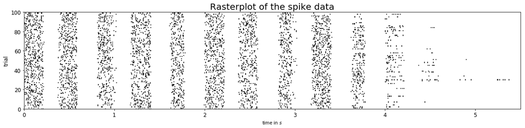

```python
#Part(a):

#Make an eventplot of the data:

def rasterplot (data, trial_length = TRIAL_LENGTH):

    plt.figure(figsize = (20,4))

    colors = ['C{}'.format(i) for i in range(10)]

    colors = np.repeat(colors, 10)

    plt.eventplot(data, color = 'black')
    plt.tick_params(labelsize=12)
    plt.xlim(0, trial_length)
    plt.ylim(0, 100)
    plt.xlabel("time in $s$")
    plt.ylabel("trial", fontsize=12);
    plt.title("Rasterplot of the spike data", fontsize = 20)


    plt.show()


rasterplot(spike_data.T)
```

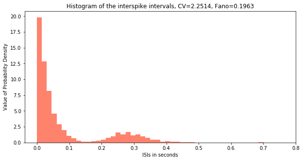

```python
#Part(b): PLot a historgram of the ISIs pooled across trials:

Pooling = NewType('Pooling', Union["Trials", "Windows"])

def ISI_pool (data, pooling: Optional[Pooling]):


    result = np.diff(data, axis=0).flatten() if data.shape[0] != 1 else np.diff(data).flatten()

    result2 = np.where(np.isnan(result), 0, result)

    #Compute CV and Fano Factor:

    cv, fano = np.round(CV(result2), decimals=4), np.round(Fano(result2),decimals=4)

    plt.figure(figsize = (10,5))
    plt.hist(result, color = 'tomato', linewidth = 15, alpha = .8, bins = 50, density = True)
    plt.title("Histogram of the interspike intervals, CV={}, Fano={}".format(cv,fano))
    plt.xlabel("ISIs in seconds")
    plt.ylabel("Value of Probability Density")

    return None


ISI_pool(spike_data, "Trials")
```

Overall, the data follows a Poisson distribution. There is an area around 300 $ms$, however, where the data looks almost normally distributed. I suspect this coming from the 'stripes' to the right of the plot above.

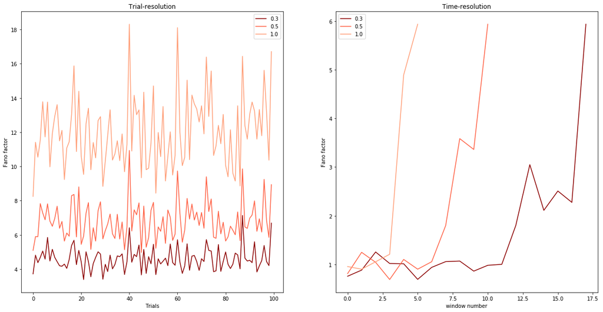

```python
windowSize = NewType('windowSize', float)

def windows(data, wS: windowSize):

    #Number of windows:

    num_windows = int(np.floor(data.shape[0]/wS))

    #Intialize return array:

    windows = np.zeros((num_windows, data.shape[1]))

    k = 0

    for col in range(windows.shape[1]):

        k = 0

        while k < num_windows:

            #Count the spikes within a window:

            windows[k, col] = len(list(filter(lambda x: k * wS <= x < (k+1) * wS, data[:,col])))

            k += 1

    if data.shape[1] != 1:

        fanoTime = [Fano(row) for row in windows]
        fanoTrials = [Fano(col) for col in windows.T]

    else:

        fanoTime = Fano(windows)
        fanoTrials = fanoTime

    return windows, fanoTime, fanoTrials

fig, axs = plt.subplots(1,2, figsize = (20,10))

colors = ['darkred', 'tomato', 'lightsalmon']

for wInd, wS in np.ndenumerate(np.array([.3,.5,1])):

    num_windows = int(np.floor(spike_data.shape[0]/wS))

    result = windows(spike_data,wS)

    #print("The Trial-resolved Fano factor for a windowsize {} is: {}".format(wS, result[2]))
    #print("The Time-resolved Fano factor for a windowsize {} is: {}".format(wS, result[1]))
    axs[0].plot(np.arange(100), result[2], c=colors[wInd[0]], label=wS)
    axs[0].set_xlabel('Trials')
    axs[0].set_ylabel('Fano factor')
    axs[0].set_title('Trial-resolution')
    axs[0].legend()
    axs[1].plot(np.arange(num_windows), result[1], c=colors[wInd[0]], label=wS)
    axs[1].set_xlabel("window number")
    axs[1].set_ylabel('Fano factor')
    axs[1].set_title('Time-resolution')
    axs[1].legend()
```

$\textbf{Exercise 2: Homogenous and inhomogenous Poisson process}$

```python
from scipy.io import loadmat

matData = loadmat("PoissonSpikeTrains.mat")

matData

stHom, stInhom, stRef, drivingRates = matData["SpikeTimes_hom"]/1000,\
matData["SpikeTimes_inh"]/1000,\
matData["SpikeTimes_ref"]/1000,\
matData["rates_ref"]
```

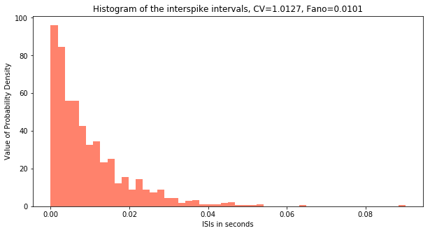

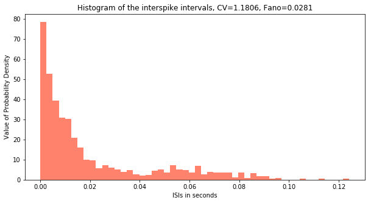

```python
ISI_pool(stHom, "Trials")
ISI_pool(stInhom, "Trials")
```

The theoretical divergence is explained by the fact that the data are still sampled using pseudorandom processes (e.g. thinning using random coinflips in the case of the inhomogenous Poisson process).

```python
#Get the spike trains:

def spike_train (spike_times, time_range):

    """
    Compute spike train:
    @params:
    spike_times: an array of spike events
    time_range: an array of times lasting covering the span
    of the entire experiment at some temporal resolutio
    """

    result = np.zeros(time_range.shape[0])

    timeT = np.round(time_range, decimals=4)

    spikeT = np.where(np.isnan(spike_times), 0, spike_times)

    spikeT = np.round(spike_times, decimals=4)

    for tI, t in np.ndenumerate(timeT):

        dirac_t = np.where(np.array(t - spikeT) == 0, 1, 0)
        result[tI] = dirac_t.sum()

    return result

#Get the trial average:

def trial_average (spike_data, num_trials, time_range):

    """
    Compute the trial-averaged spike train:
    @params:
    spike_data: ----"----
    num_trials: The number of trials over which to take the average
    time_range: ----"----

    """

    result = np.zeros((num_trials, time_range.shape[0]))

    for trial in range(num_trials):

        result[trial,:] = spike_train(spike_data[:,trial], time_range)

    return result.mean(axis = 0)

#Compute the auto correlation:

def auto_cor (data, trial_times):

    tav = trial_average(data, data.shape[1], trial_times)

    result = np.correlate(tav, tav, "same")

    return result

spike_auto_correlation = auto_cor(spike_data, trial_times)
```

```
(55000,)
```

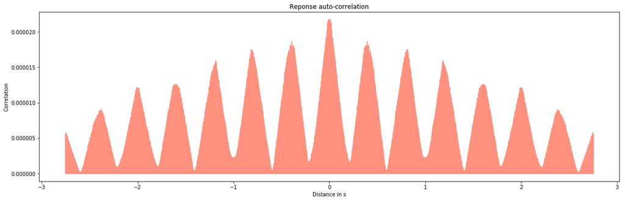

```python
#Calculate the trial averaged firing rate:

firing_rate = np.where(spike_data_cleaned > 0, 1, 0).sum(axis=0).mean() / TRIAL_LENGTH

spike_auto_correlation[spike_auto_correlation.argmax()] = 0
nw_cor = spike_auto_correlation * dt

print(nw_cor.shape)

def plot_auto_cor(data, trial_length, dt):

    plt.figure(figsize = (20,6))

    plt.plot(np.arange(-trial_length/2, trial_length/2, dt), data, c = 'tomato', alpha=.7)
    plt.xlabel("Distance in s")
    plt.ylabel("Correlation")
    plt.title("Reponse auto-correlation")
    plt

    plt.show()

plot_auto_cor(nw_cor, 5.5, dt)
```

That strikes me as a bit odd. Shouldn't the correlation be bigger? In any case it seems that there is definite correlations between bins at certain distances, so that the spike trains show clear frequencies.

$\textbf{Exercise 3: Poisson process with refractory period}$

```
[  9.63473599  40.39062063  67.20831374 100.60811776 143.3522751
 167.00314574]
```

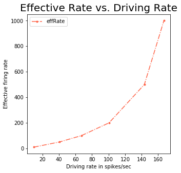

```python
#Part a:

#Effective rate = oveall duration / #spikes (=1000):

effRates = 1000 / stRef[999,:]
print(effRates)

plt.figure(figsize = (5,5))

plt.plot(effRates, drivingRates[0], '.-.', c='tomato', label = "effRate")
plt.title("Effective Rate vs. Driving Rate", fontsize = 20)
plt.xlabel("Driving rate in spikes/sec")
plt.ylabel("Effective firing rate")
plt.legend()
```

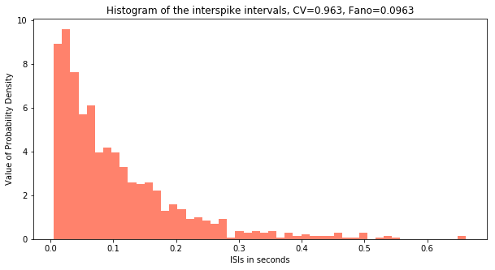

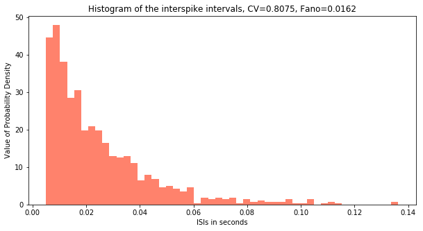

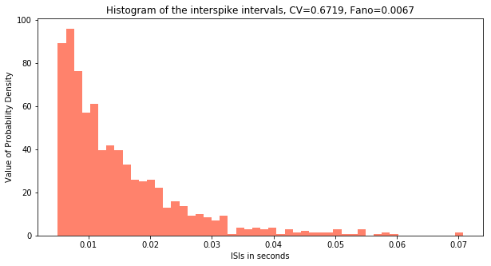

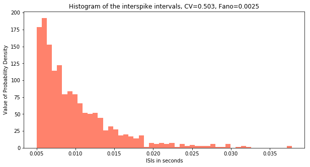

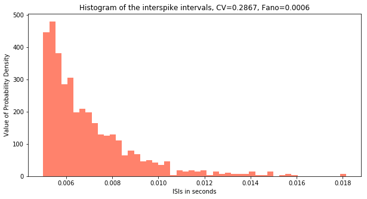

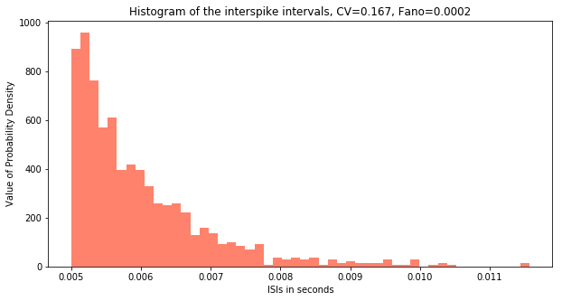

```python
#Part b:

for col in stRef.T:

    ISI_pool(col, "Trials")
```

We can see that the distributions look the same, only that they become distributions over increasingly smaller intervals. This explains why the Fano factor decreases. The variance and the mean both decrease, but the variance decreases quadratically. So the numerator goes against zero faster than the denominator, which is why the full expression evaluates to smaller and smaller values.

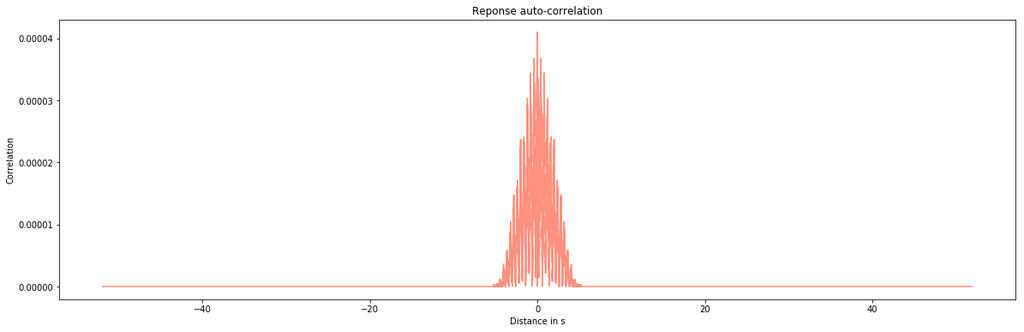

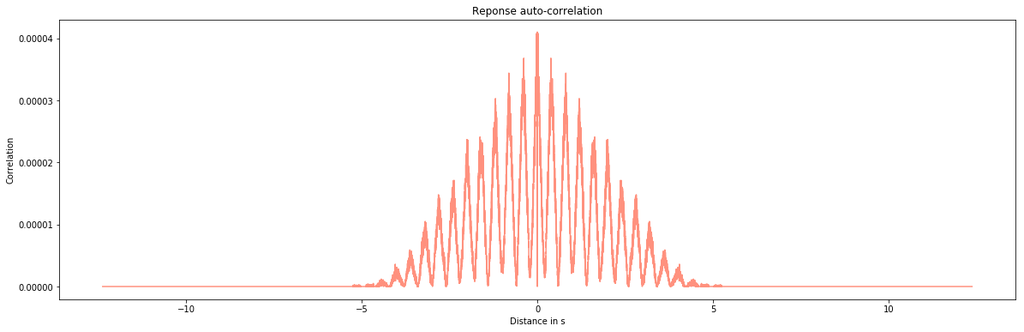

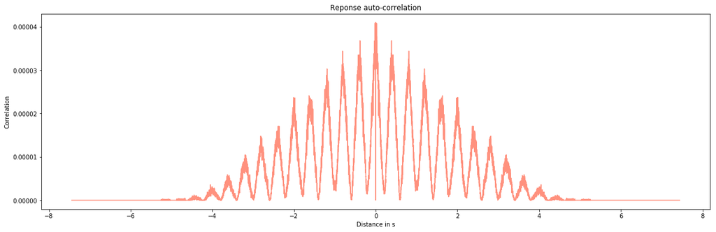

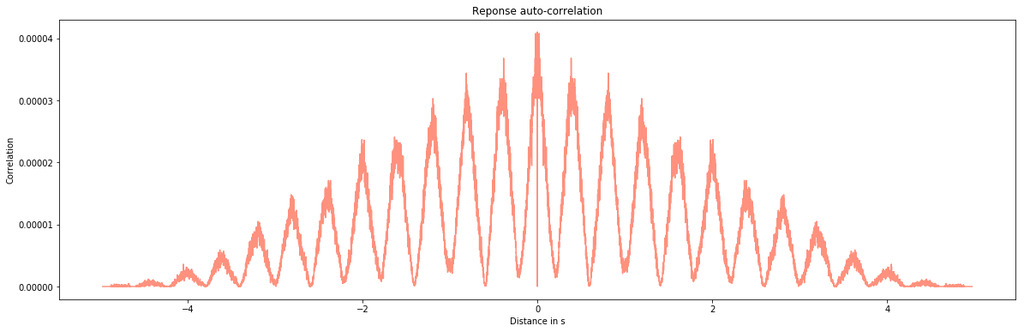

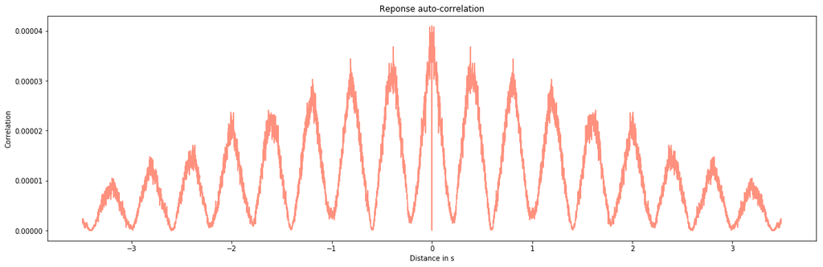

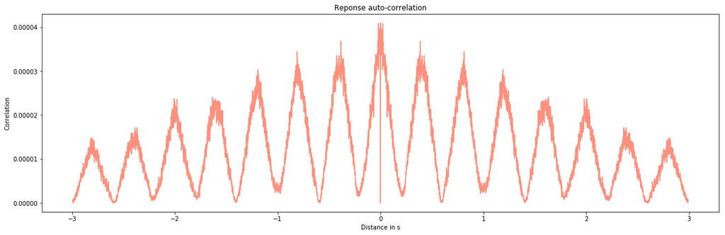

```python
#Part(d):

dt2 = .001

for col in (stRef.T):

    trialTs = np.arange(0,col[-1], dt2)

    res = auto_cor(spike_data, trialTs)
    res[res.argmax()] = 0

    plot_auto_cor(res * dt2, col[-1], dt2)
```

$\textbf{Bonus Exercise 4}$

```
The CV for the 2th gamma process is: 0.6835
The Fano factor for the 2th gamma process is: 9.181
The CV for the 3th gamma process is: 0.5863
The Fano factor for the 3th gamma process is: 10.1399
The CV for the 5th gamma process is: 0.4426
The Fano factor for the 5th gamma process is: 9.9195
The CV for the 10th gamma process is: 0.3157
The Fano factor for the 10th gamma process is: 9.9277
```

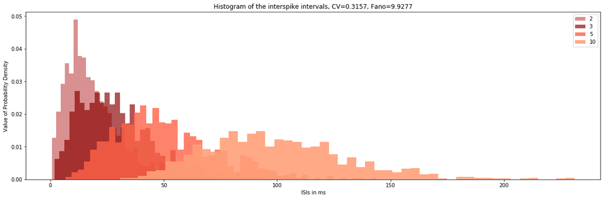

```python
#Use procedure from generatePoisson to generate homogenous Poisson spikeTrain:

def hom_poisson(n, rate):

    randNumbers = np.random.rand(n)
    ISIs = -np.log(randNumbers)/rate
    ISIs = ISIs*1000 #to ms

    return np.cumsum(ISIs)

#Parameters for the k-Gamma processes:

K = np.array([2,3,5,10])

'''
Generate matrix for the gamma processes: each row will contain
hundred spikes from one gamma process with k in K

'''

Gamma = np.zeros((len(K), 1000))

for kI, k in np.ndenumerate(K):


    #Generates a homogenous Poisson with k*n evenst keeping only each kth event:

    hom = hom_poisson(k*1000, 100)
    gamma = hom[0:k*1000:k]

    Gamma[kI,:] = gamma


#Part(b): Compute histograms and CVS:

plt.figure(figsize = (20,6))

colors = ['firebrick','darkred', 'tomato', 'lightsalmon', 'coral']

rowI = 0
for row in Gamma:

    color = colors[rowI]

    result = np.diff(row).flatten()

    cv, fano = np.round(CV(result), decimals=4), np.round(Fano(result),decimals=4)

    print('The CV for the {}th gamma process is: {}'.format(K[rowI], cv))
    print('The Fano factor for the {}th gamma process is: {}'.format(K[rowI], fano))

    plt.hist(result, color=color, linewidth = 15, alpha = 1 - 1 / K[rowI], bins = 50, density = True, label= K[rowI])
    plt.title("Histogram of the interspike intervals, CV={}, Fano={}".format(cv,fano))
    plt.xlabel("ISIs in ms")
    plt.ylabel("Value of Probability Density")
    plt.legend()

    rowI += 1
```

```python
from scipy.special import factorial

def pISI (t, k, rate=100):

    num = rate * (rate * t)**(k - 1) * np.exp(-rate * t)
    denom = factorial(k-1)

    return num / denom
```

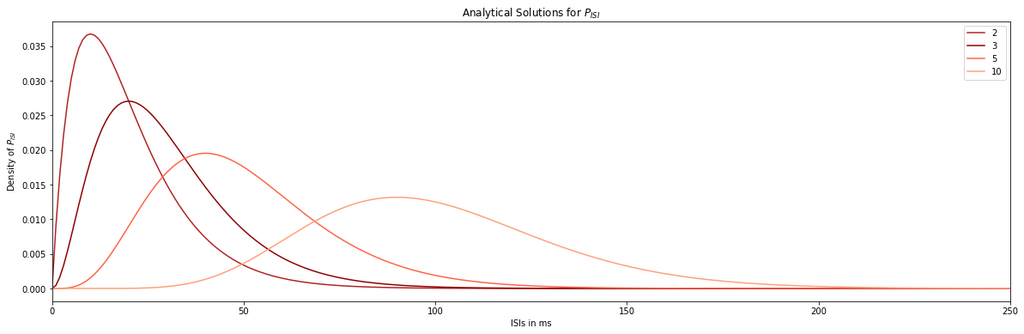

```python
plt.figure(figsize = (20,6))

for kI, k in np.ndenumerate(K):

    time_range = np.arange(0,2,.001)

    psi_partial = lambda t: pISI(t,k)
    np.vectorize(psi_partial)
    #convert to ms and make into density:
    plt.plot(time_range*1000, psi_partial(time_range) / 1000, color=colors[kI[0]], label = k)
    plt.xlim(0,250)
    plt.title(r'Analytical Solutions for $P_{ISI}$')
    plt.xlabel("ISIs in ms")
    plt.ylabel(r"Density of $P_{ISI}$")
    plt.legend()
```

Comparing the results we can see that they match fairly well. For higher $ks$, the distribution approaches a Gaussian curve, which is the thereotical resutl. The histogram should then look more and more like a binomial distribution, which it does.